# Exercise 3.2

## Author: Lara Mechling

### Date: 3/27/2022

# US Population Data

## Import Libraries

```python
import pandas as pd
import matplotlib.pyplot as plt
import numpy as np
from sklearn.metrics import r2_score
import math
```

## Import CSV file

```python
population = pd.read_csv('us_pop_data.csv')
population
```

|  | year | us_pop |
| --- | --- | --- |
| 0 | 1790 | 3929326 |
| 1 | 1800 | 5308483 |
| 2 | 1810 | 7239881 |
| 3 | 1820 | 9638453 |
| 4 | 1830 | 12866020 |
| 5 | 1840 | 17069453 |
| 6 | 1850 | 23191876 |
| 7 | 1860 | 31443321 |
| 8 | 1870 | 39818449 |
| 9 | 1880 | 50189209 |
| 10 | 1890 | 62947714 |
| 11 | 1900 | 76212168 |
| 12 | 1910 | 92228496 |
| 13 | 1920 | 106021537 |
| 14 | 1930 | 122775046 |
| 15 | 1940 | 132164569 |
| 16 | 1950 | 150697361 |
| 17 | 1960 | 179323175 |
| 18 | 1970 | 203302031 |
| 19 | 1980 | 226545805 |
| 20 | 1990 | 248709873 |
| 21 | 2000 | 281421906 |
| 22 | 2010 | 308745538 |

## Add two columns and generate data

```python
population['years_since'] = population['year'] - 1790
population['pop_millions'] = population['us_pop'].astype(float)/1000000
pd.options.display.float_format = '{:.2f}'.format
population
```

|  | year | us_pop | years_since | pop_millions |
| --- | --- | --- | --- | --- |
| 0 | 1790 | 3929326 | 0 | 3.93 |
| 1 | 1800 | 5308483 | 10 | 5.31 |
| 2 | 1810 | 7239881 | 20 | 7.24 |
| 3 | 1820 | 9638453 | 30 | 9.64 |
| 4 | 1830 | 12866020 | 40 | 12.87 |
| 5 | 1840 | 17069453 | 50 | 17.07 |
| 6 | 1850 | 23191876 | 60 | 23.19 |
| 7 | 1860 | 31443321 | 70 | 31.44 |
| 8 | 1870 | 39818449 | 80 | 39.82 |
| 9 | 1880 | 50189209 | 90 | 50.19 |
| 10 | 1890 | 62947714 | 100 | 62.95 |
| 11 | 1900 | 76212168 | 110 | 76.21 |
| 12 | 1910 | 92228496 | 120 | 92.23 |
| 13 | 1920 | 106021537 | 130 | 106.02 |
| 14 | 1930 | 122775046 | 140 | 122.78 |
| 15 | 1940 | 132164569 | 150 | 132.16 |
| 16 | 1950 | 150697361 | 160 | 150.70 |
| 17 | 1960 | 179323175 | 170 | 179.32 |
| 18 | 1970 | 203302031 | 180 | 203.30 |
| 19 | 1980 | 226545805 | 190 | 226.55 |
| 20 | 1990 | 248709873 | 200 | 248.71 |
| 21 | 2000 | 281421906 | 210 | 281.42 |
| 22 | 2010 | 308745538 | 220 | 308.75 |

## Plot years since 1790 v. US population

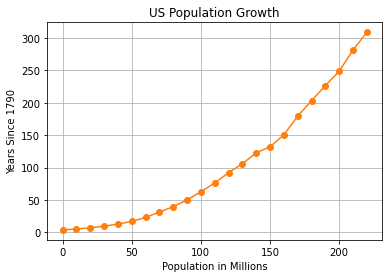

```python
plt.plot(population['years_since'], population['pop_millions'], marker = 'o',
         color = 'C1')
plt.xlabel('Population in Millions')
plt.ylabel('Years Since 1790')
plt.title('US Population Growth')

plt.grid()

plt.show()
```

## Create a linear regression model to fit the data

```python
years_since = np.array(population.years_since)
pop_millions = np.array(population.pop_millions)
a, b = np.polyfit(years_since, pop_millions, 1)

print("Using numpy's polyfit function:")
print(f"\nThe slope of the line is {a}.")
print(f"The y-inercept of the line is {b}.")
print(f"\n The equation of the line is y={a}x + {b}.")
```

```
Using numpy's polyfit function:

The slope of the line is 1.3596248380434786.
The y-inercept of the line is -45.56787609782605.

 The equation of the line is y=1.3596248380434786x + -45.56787609782605.
```

## Calculate R^2 of linear line of best fit

```python
# Create column with predicted linear values
population['linear_est'] = a * population['years_since'] + b
linear_est = np.array(population.linear_est)

# Calculate R^2 score of predicted linear values
r2_linear = r2_score(pop_millions, linear_est)
print(r2_linear)
```

```
0.9192437447080442
```

## Create a column of squared number of years since 1790

```python
population['squared_years'] = population['years_since'] ** 2
population
```

|  | year | us_pop | years_since | pop_millions | linear_est | squared_years |
| --- | --- | --- | --- | --- | --- | --- |
| 0 | 1790 | 3929326 | 0 | 3.93 | -45.57 | 0 |
| 1 | 1800 | 5308483 | 10 | 5.31 | -31.97 | 100 |
| 2 | 1810 | 7239881 | 20 | 7.24 | -18.38 | 400 |
| 3 | 1820 | 9638453 | 30 | 9.64 | -4.78 | 900 |
| 4 | 1830 | 12866020 | 40 | 12.87 | 8.82 | 1600 |
| 5 | 1840 | 17069453 | 50 | 17.07 | 22.41 | 2500 |
| 6 | 1850 | 23191876 | 60 | 23.19 | 36.01 | 3600 |
| 7 | 1860 | 31443321 | 70 | 31.44 | 49.61 | 4900 |
| 8 | 1870 | 39818449 | 80 | 39.82 | 63.20 | 6400 |
| 9 | 1880 | 50189209 | 90 | 50.19 | 76.80 | 8100 |
| 10 | 1890 | 62947714 | 100 | 62.95 | 90.39 | 10000 |
| 11 | 1900 | 76212168 | 110 | 76.21 | 103.99 | 12100 |
| 12 | 1910 | 92228496 | 120 | 92.23 | 117.59 | 14400 |
| 13 | 1920 | 106021537 | 130 | 106.02 | 131.18 | 16900 |
| 14 | 1930 | 122775046 | 140 | 122.78 | 144.78 | 19600 |
| 15 | 1940 | 132164569 | 150 | 132.16 | 158.38 | 22500 |
| 16 | 1950 | 150697361 | 160 | 150.70 | 171.97 | 25600 |
| 17 | 1960 | 179323175 | 170 | 179.32 | 185.57 | 28900 |
| 18 | 1970 | 203302031 | 180 | 203.30 | 199.16 | 32400 |
| 19 | 1980 | 226545805 | 190 | 226.55 | 212.76 | 36100 |
| 20 | 1990 | 248709873 | 200 | 248.71 | 226.36 | 40000 |
| 21 | 2000 | 281421906 | 210 | 281.42 | 239.95 | 44100 |
| 22 | 2010 | 308745538 | 220 | 308.75 | 253.55 | 48400 |

## Create a linear regression model to fit the squared years since 1790

```python
squared_years = np.array(population.squared_years)
c, d = np.polyfit(squared_years, pop_millions, 1)

print("Using numpy's polyfit function:")
print(f"\nThe slope of the line is {c}.")
print(f"The y-inercept of the line is {d}.")
print(f"\n The equation of the line is y={c}x + {d}.")
```

```
Using numpy's polyfit function:

The slope of the line is 0.006220027007947028.
The y-inercept of the line is 1.3604104558306371.

 The equation of the line is y=0.006220027007947028x + 1.3604104558306371.
```

## Calculate R^2 of linear line of best fit

```python
# Create column with predicted linear values
population['squared_est'] = c * population['squared_years'] + d
squared_est = np.array(population.squared_est)

# Calculate R^2 score of predicted linear values
r2_linear = r2_score(pop_millions, squared_est)
print(r2_linear)

population
```

```
0.9984915694986646
```

|  | year | us_pop | years_since | pop_millions | linear_est | squared_years | squared_est |
| --- | --- | --- | --- | --- | --- | --- | --- |
| 0 | 1790 | 3929326 | 0 | 3.93 | -45.57 | 0 | 1.36 |
| 1 | 1800 | 5308483 | 10 | 5.31 | -31.97 | 100 | 1.98 |
| 2 | 1810 | 7239881 | 20 | 7.24 | -18.38 | 400 | 3.85 |
| 3 | 1820 | 9638453 | 30 | 9.64 | -4.78 | 900 | 6.96 |
| 4 | 1830 | 12866020 | 40 | 12.87 | 8.82 | 1600 | 11.31 |
| 5 | 1840 | 17069453 | 50 | 17.07 | 22.41 | 2500 | 16.91 |
| 6 | 1850 | 23191876 | 60 | 23.19 | 36.01 | 3600 | 23.75 |
| 7 | 1860 | 31443321 | 70 | 31.44 | 49.61 | 4900 | 31.84 |
| 8 | 1870 | 39818449 | 80 | 39.82 | 63.20 | 6400 | 41.17 |
| 9 | 1880 | 50189209 | 90 | 50.19 | 76.80 | 8100 | 51.74 |
| 10 | 1890 | 62947714 | 100 | 62.95 | 90.39 | 10000 | 63.56 |
| 11 | 1900 | 76212168 | 110 | 76.21 | 103.99 | 12100 | 76.62 |
| 12 | 1910 | 92228496 | 120 | 92.23 | 117.59 | 14400 | 90.93 |
| 13 | 1920 | 106021537 | 130 | 106.02 | 131.18 | 16900 | 106.48 |
| 14 | 1930 | 122775046 | 140 | 122.78 | 144.78 | 19600 | 123.27 |
| 15 | 1940 | 132164569 | 150 | 132.16 | 158.38 | 22500 | 141.31 |
| 16 | 1950 | 150697361 | 160 | 150.70 | 171.97 | 25600 | 160.59 |
| 17 | 1960 | 179323175 | 170 | 179.32 | 185.57 | 28900 | 181.12 |
| 18 | 1970 | 203302031 | 180 | 203.30 | 199.16 | 32400 | 202.89 |
| 19 | 1980 | 226545805 | 190 | 226.55 | 212.76 | 36100 | 225.90 |
| 20 | 1990 | 248709873 | 200 | 248.71 | 226.36 | 40000 | 250.16 |
| 21 | 2000 | 281421906 | 210 | 281.42 | 239.95 | 44100 | 275.66 |
| 22 | 2010 | 308745538 | 220 | 308.75 | 253.55 | 48400 | 302.41 |

## Plot data and regression models

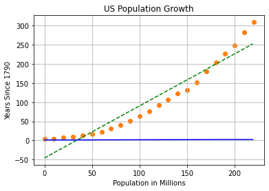

```python
x = np.arange(220)
y = a * x + b

w = np.arange(220)
z = c * w + d

linear_line = plt.plot(x, y, '--g', label = 'y = 1.36x - 45.57')
squared_line = plt.plot(w, z, '-b', label = 'y = 0.006x + 1.36')

plt.scatter(population['years_since'], population['pop_millions'], marker = 'o',
         color = 'C1')
plt.xlabel('Population in Millions')
plt.ylabel('Years Since 1790')
plt.title('US Population Growth')

plt.grid()

plt.show()
```

# Which model fits the data better?

Based on the R2 value the model using the squared data fits the equation better. This value is the closest to 1.0 which means a perfect fit of the data.

I am struggling to get my graph of the second equation to show up correctly. After grading the assignment I would like to work with you to see how this could be accomplished correctly.

# Customer Spending Data

## Import CSV Files

```python
spending = pd.read_csv('customer_spending.csv')
spending
```

|  | ann_spending |
| --- | --- |
| 0 | 34112 |
| 1 | 33266 |
| 2 | 36610 |
| 3 | 27381 |
| 4 | 46100 |
| ... | ... |
| 435 | 73302 |
| 436 | 48372 |
| 437 | 77407 |
| 438 | 17834 |
| 439 | 7589 |

440 rows × 1 columns

## Make histogram of customer spending data

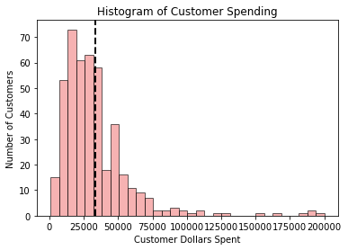

```python
# Convert to numpy array
ann_spending = np.array(spending.ann_spending)

# Create histogram
plt.hist(ann_spending, bins='auto', edgecolor='black', color='lightcoral', alpha=0.6)
plt.xlabel('Customer Dollars Spent')
plt.ylabel('Number of Customers')
plt.title('Histogram of Customer Spending')
plt.axvline(ann_spending.mean(), color='black', linestyle='dashed', linewidth=2
           )
plt.show()
```

## Log transformation of customer spending amounts

```python
# Create column with log values
spending['log_spending'] = np.log2(spending['ann_spending'])
log_spending = np.array(spending.log_spending)

spending
```

|  | ann_spending | log_spending |
| --- | --- | --- |
| 0 | 34112 | 15.057992 |
| 1 | 33266 | 15.021761 |
| 2 | 36610 | 15.159950 |
| 3 | 27381 | 14.740888 |
| 4 | 46100 | 15.492479 |
| ... | ... | ... |
| 435 | 73302 | 16.161565 |
| 436 | 48372 | 15.561885 |
| 437 | 77407 | 16.240176 |
| 438 | 17834 | 14.122343 |
| 439 | 7589 | 12.889694 |

440 rows × 2 columns

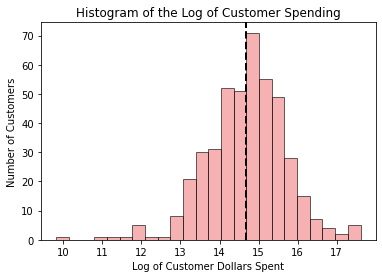

```python
# Create histogram
plt.hist(log_spending, bins='auto', edgecolor='black', color='lightcoral', alpha=0.6)
plt.xlabel('Log of Customer Dollars Spent')
plt.ylabel('Number of Customers')
plt.title('Histogram of the Log of Customer Spending')
plt.axvline(log_spending.mean(), color='black', linestyle='dashed', linewidth=2)

plt.show()
```

## Why is it useful to apply a log transformation?

Log functions will show a relative change in customer spending, where the base historgram showed to absolute change in customer spending. For example, the absolute graph shows the exact number of dollars the customer spending changed, but the log transformation shows the percentage of relative change in customer spending. In this example I think you would need to know exactly what information you are looking to glean from the histograms. If you want to know how much the majority of your customers are spending I would use the graph of the absolute values of spending. If you want to know the relative change in customer sending as it increases, use the logrithmic graph. (I do not know if this is correct. I may reach out to you once you have graded the assignment to go over it further).